# 4RTNI - v6

SHORT cutoff:

```r
SHORT_CUTOFF
```

```
## [1] 2
```

LONG cutoff:

```r
LONG_CUTOFF
```

```
## [1] 5
```

VERY LONG cutoff

```r
VERYLONG_CUTOFF
```

```
## [1] 10
```

```r
mydata_long %>% count(diagnosis,disease_duration_category)
```

```
## Source: local data frame [4 x 3]
## Groups: diagnosis [?]
##
## # A tibble: 4 x 3
##   diagnosis disease_duration_category     n
##      <fctr>                    <fctr> <int>
## 1       CBS                     SHORT     8
## 2       CBS                      LONG    10
## 3       PSP                     SHORT     8
## 4       PSP                      LONG    12
```

# Total Grey Matter Volume

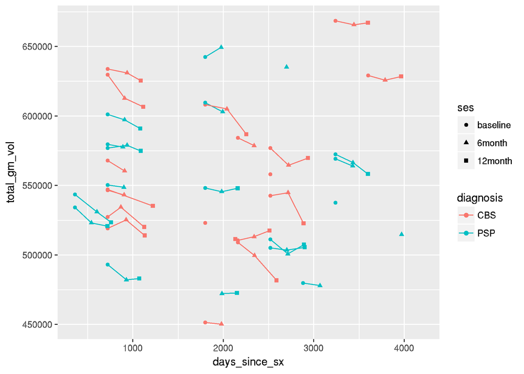

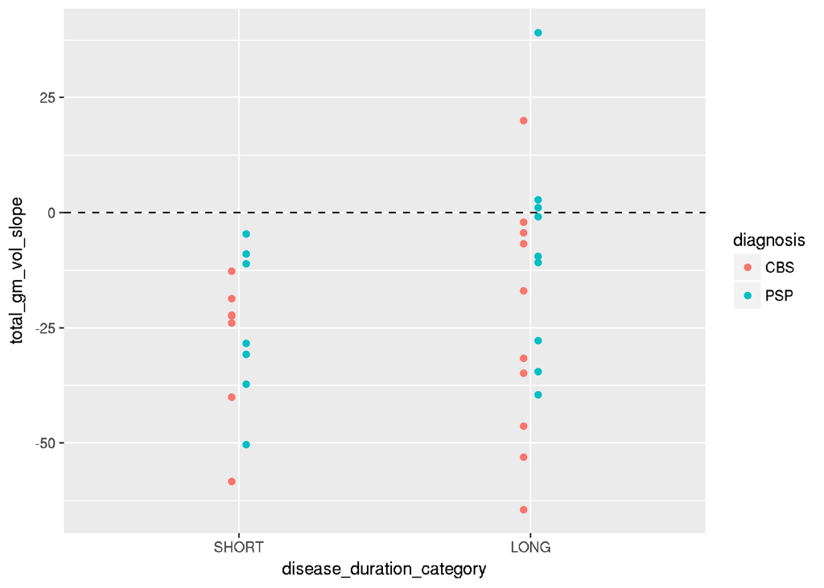

t.test for SHORT vs LONG group diff in slope among CBS:

```r
t.test(total_gm_vol_slope~disease_duration_category, data=mydata_long,subset= diagnosis=="CBS")$p.value
```

```
## [1] 0.6809166
```

t.test for SHORT vs LONG group diff in slope among PSP:

```r
t.test(total_gm_vol_slope~disease_duration_category, data=mydata_long,subset= diagnosis=="PSP")$p.value
```

```
## [1] 0.1484854
```

# Total White Matter Volume

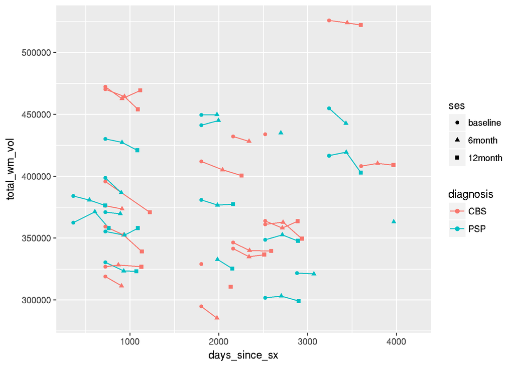

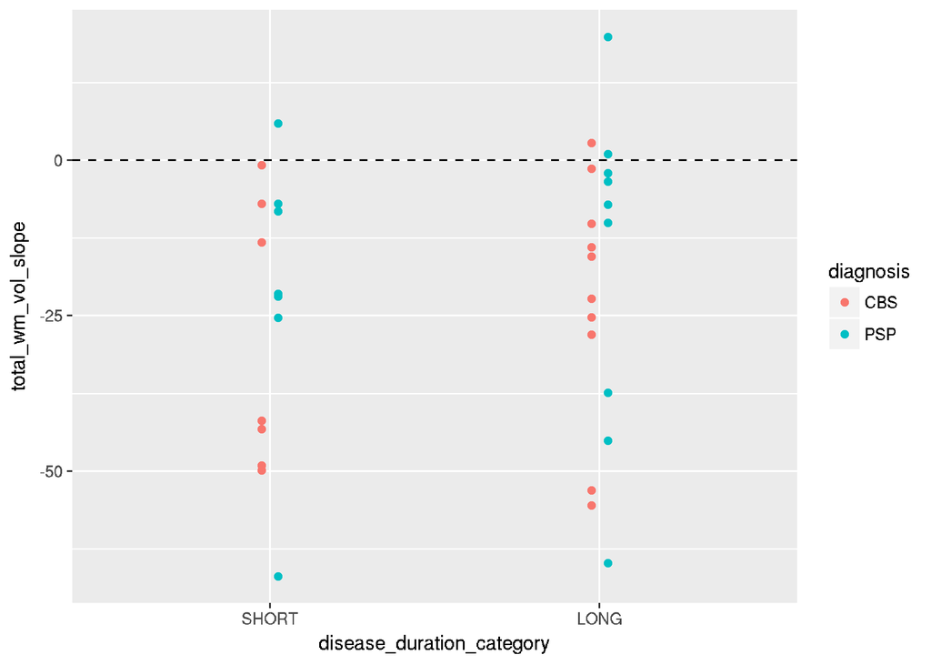

t.test for SHORT vs LONG group diff in slope among CBS:

```r
t.test(total_wm_vol_slope~disease_duration_category, data=mydata_long,subset= diagnosis=="CBS")$p.value
```

```
## [1] 0.5004565
```

t.test for SHORT vs LONG group diff in slope among PSP:

```r
t.test(total_wm_vol_slope~disease_duration_category, data=mydata_long,subset= diagnosis=="PSP")$p.value
```

```
## [1] 0.7456574
```

# ======== Diffusion Measures =========

# Superior Cerebellar Peduncle FA

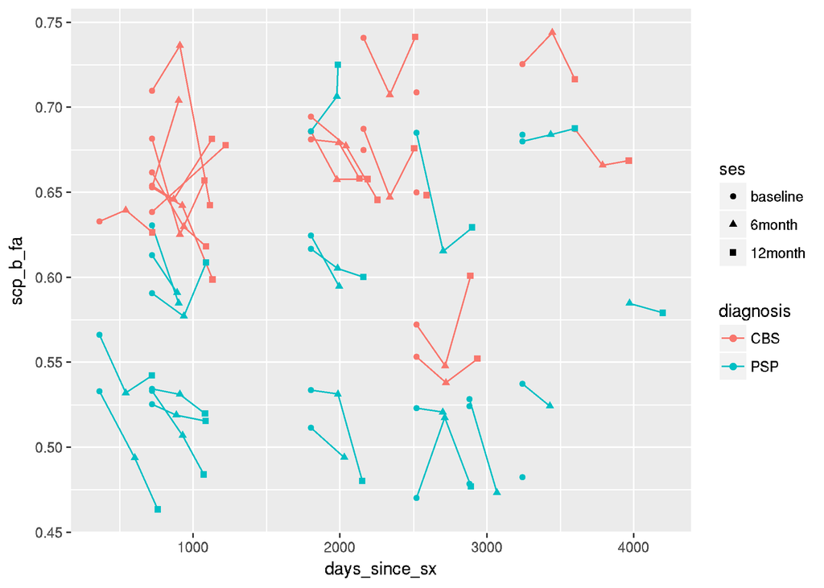

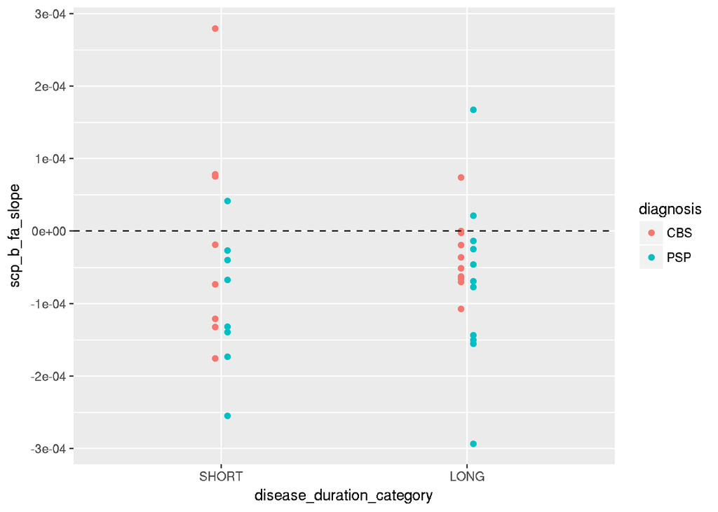

t.test for SHORT vs LONG group diff in slope among CBS:

```r
t.test(scp_b_fa_slope~disease_duration_category, data=mydata_long,subset= diagnosis=="CBS")$p.value
```

```
## [1] 0.6874143
```

t.test for SHORT vs LONG group diff in slope among PSP:

```r
t.test(scp_b_fa_slope~disease_duration_category, data=mydata_long,subset= diagnosis=="PSP")$p.value
```

```
## [1] 0.4638942
```

# Body of the Corpus Callosum FA

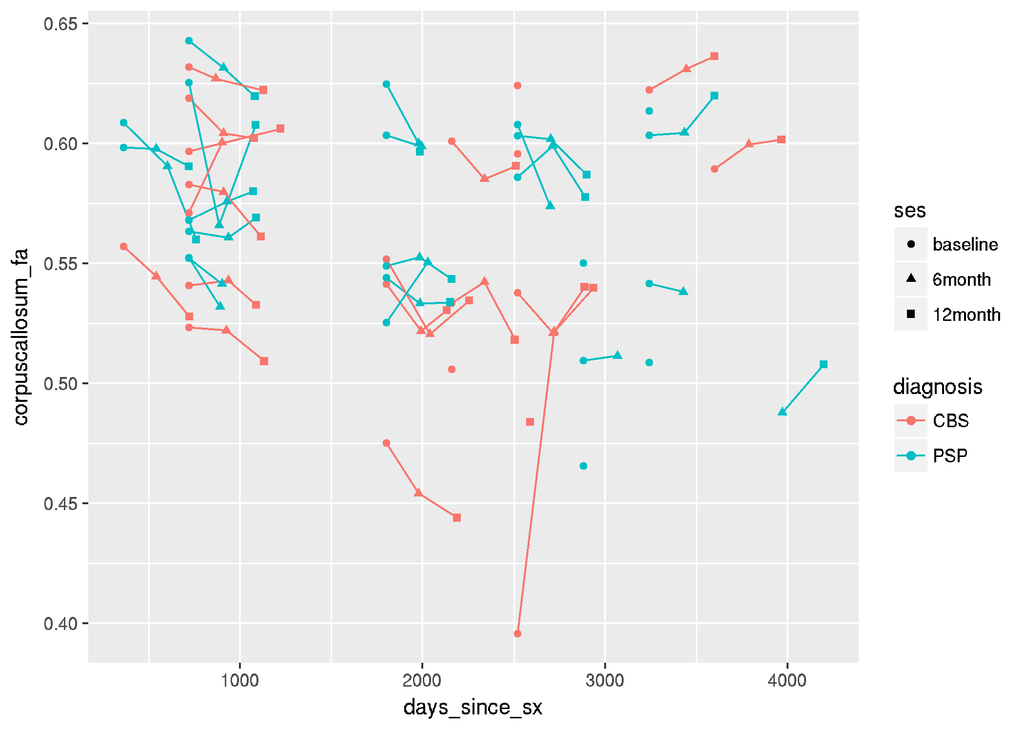

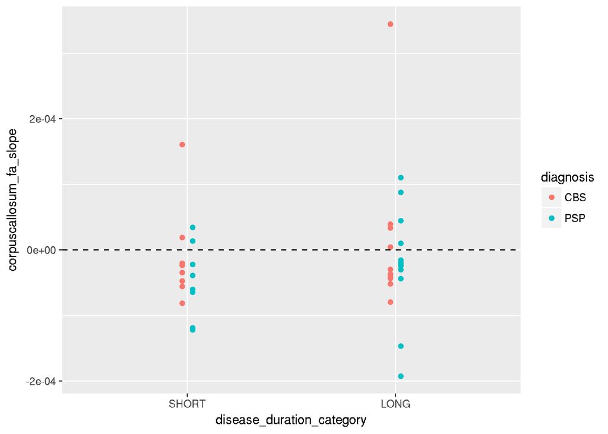

t.test for SHORT vs LONG group diff in slope among CBS:

```r
t.test(corpuscallosum_fa_slope~disease_duration_category, data=mydata_long,subset= diagnosis=="CBS")$p.value
```

```
## [1] 0.6102331
```

t.test for SHORT vs LONG group diff in slope among PSP:

```r
t.test(corpuscallosum_fa_slope~disease_duration_category, data=mydata_long,subset= diagnosis=="PSP")$p.value
```

```
## [1] 0.4015449
```

# Caudate MD

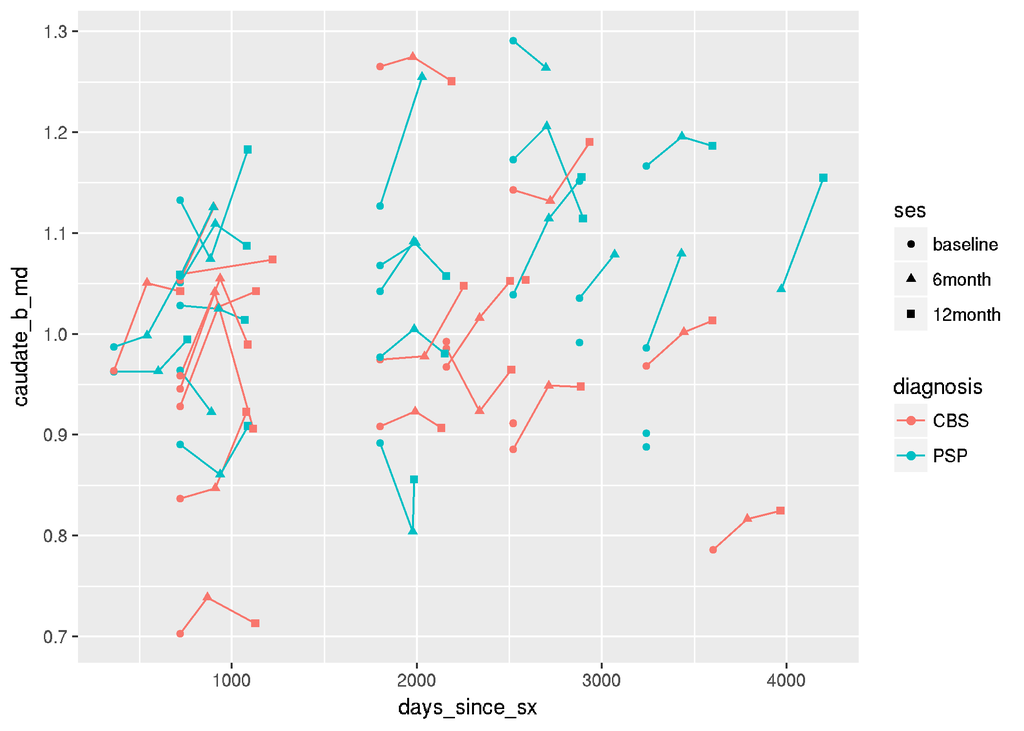

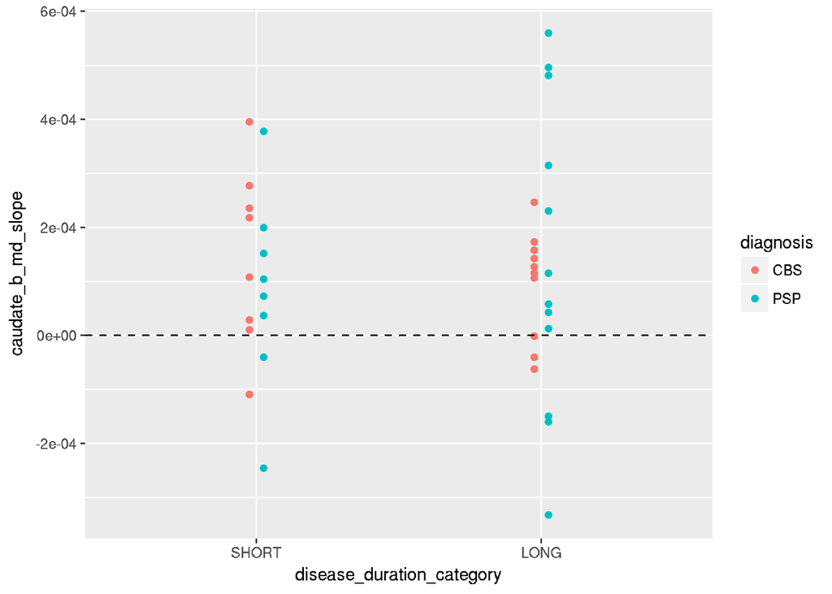

t.test for SHORT vs LONG group diff in slope among CBS:

```r
t.test(caudate_b_md_slope~disease_duration_category, data=mydata_long,subset= diagnosis=="CBS")$p.value
```

```
## [1] 0.4752357
```

t.test for SHORT vs LONG group diff in slope among PSP:

```r
t.test(caudate_b_md_slope~disease_duration_category, data=mydata_long,subset= diagnosis=="PSP")$p.value
```

```
## [1] 0.5920197
```

# Thalamus MD

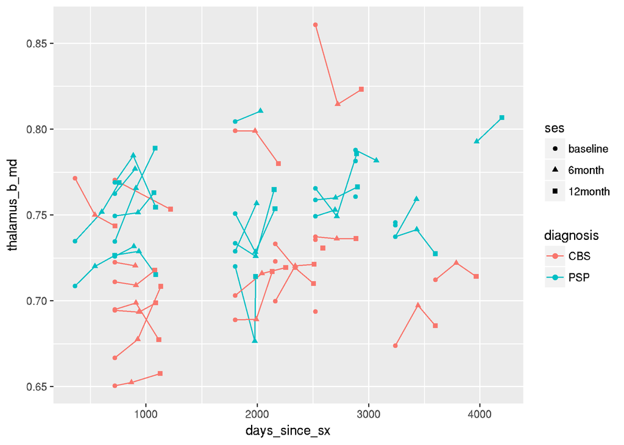

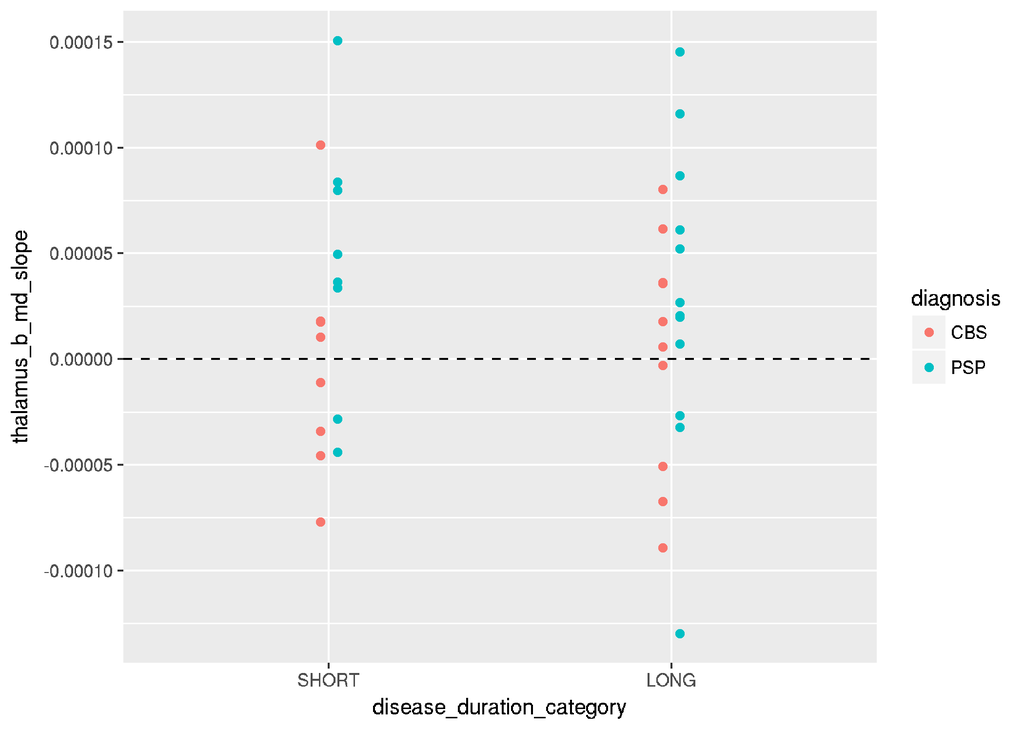

t.test for SHORT vs LONG group diff in slope among CBS:

```r
t.test(thalamus_b_md_slope~disease_duration_category, data=mydata_long,subset= diagnosis=="CBS")$p.value
```

```
## [1] 0.8415439
```

t.test for SHORT vs LONG group diff in slope among PSP:

```r
t.test(thalamus_b_md_slope~disease_duration_category, data=mydata_long,subset= diagnosis=="PSP")$p.value
```

```
## [1] 0.6013436
```

# Midbrain MD

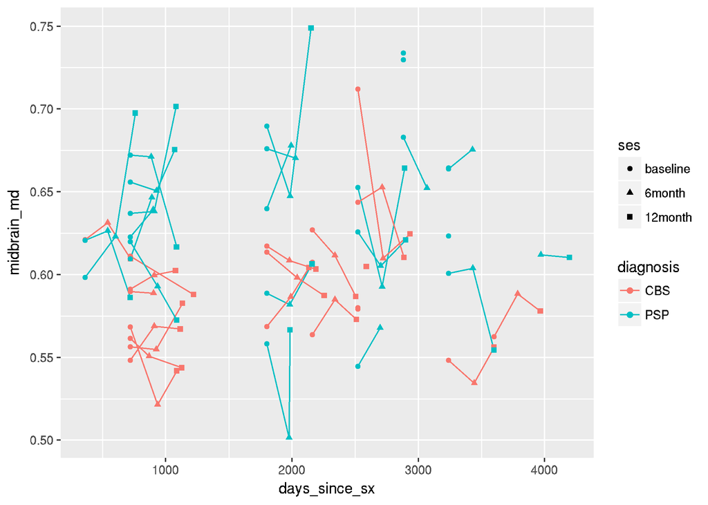

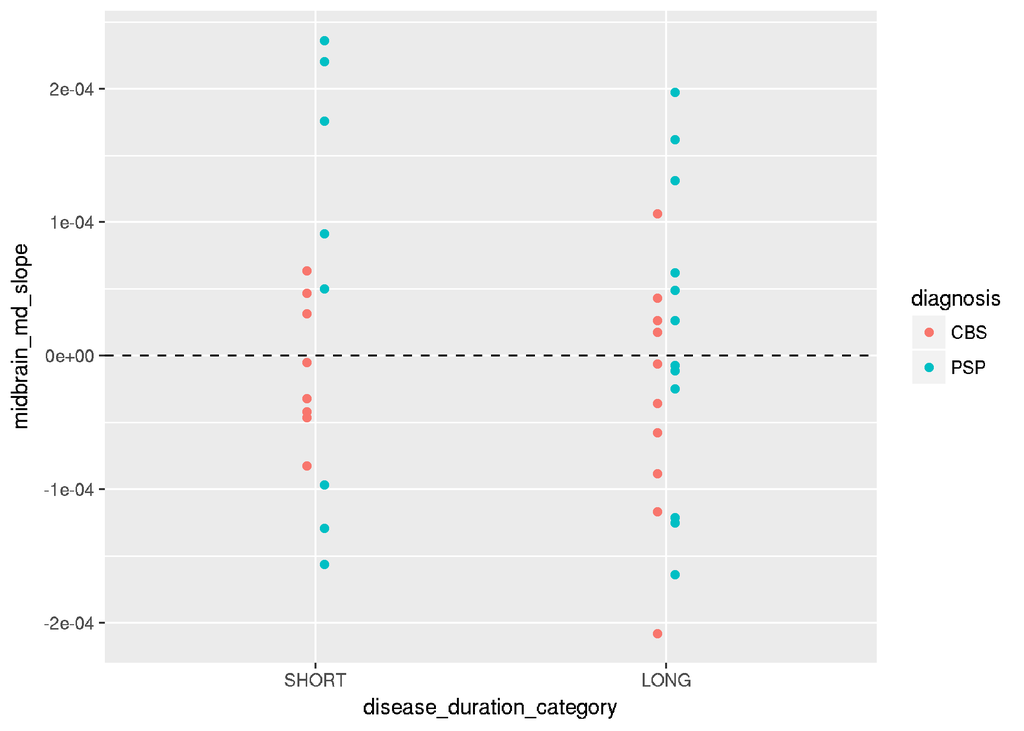

t.test for SHORT vs LONG group diff in slope among CBS:

```r
t.test(midbrain_md_slope~disease_duration_category, data=mydata_long,subset= diagnosis=="CBS")$p.value
```

```
## [1] 0.4955176
```

t.test for SHORT vs LONG group diff in slope among PSP:

```r
t.test(midbrain_md_slope~disease_duration_category, data=mydata_long,subset= diagnosis=="PSP")$p.value
```

```
## [1] 0.607605
```

# Precentral FA

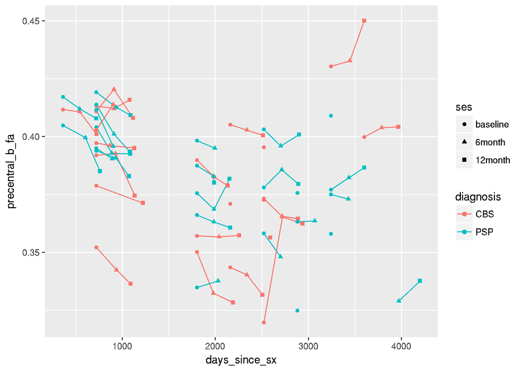

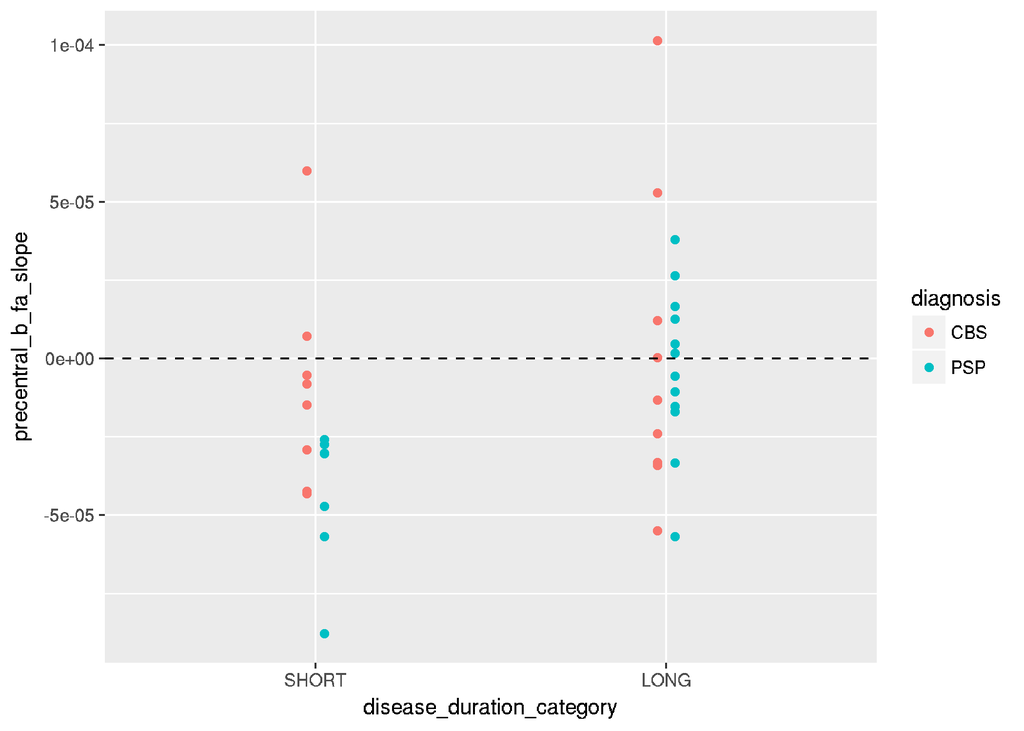

t.test for SHORT vs LONG group diff in slope among CBS:

```r
t.test(precentral_b_fa_slope~disease_duration_category, data=mydata_long,subset= diagnosis=="CBS")$p.value
```

```
## [1] 0.7243509
```

t.test for SHORT vs LONG group diff in slope among PSP:

```r
t.test(precentral_b_fa_slope~disease_duration_category, data=mydata_long,subset= diagnosis=="PSP")$p.value
```

```
## [1] 0.002327458
```

# Postcentral FA

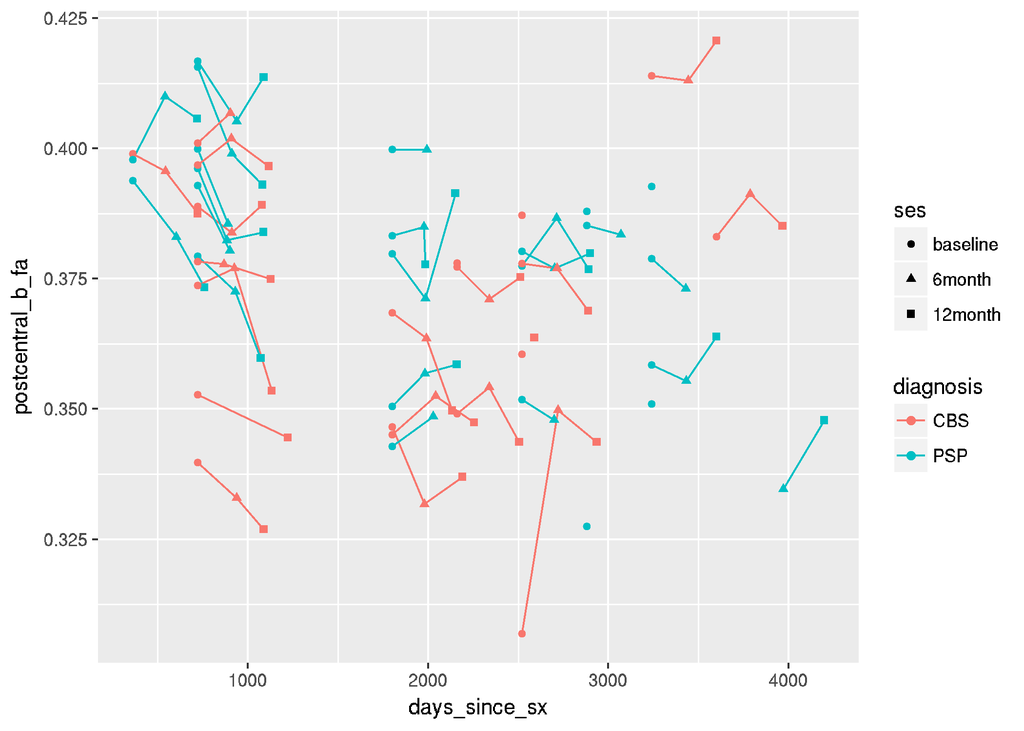

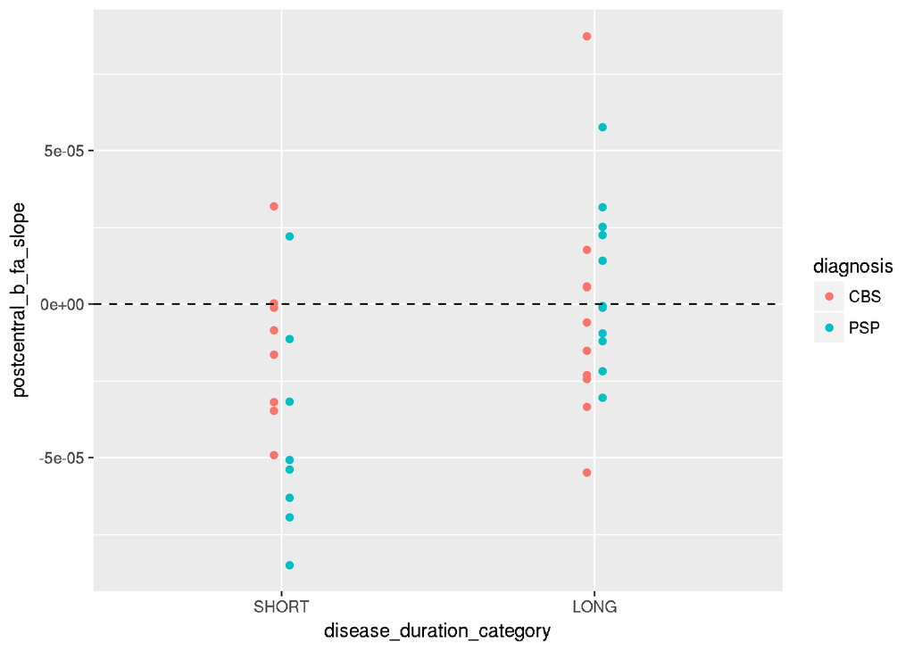

t.test for SHORT vs LONG group diff in slope among CBS:

```r
t.test(postcentral_b_fa_slope~disease_duration_category, data=mydata_long,subset= diagnosis=="CBS")$p.value
```

```
## [1] 0.5315987
```

t.test for SHORT vs LONG group diff in slope among PSP:

```r
t.test(postcentral_b_fa_slope~disease_duration_category, data=mydata_long,subset= diagnosis=="PSP")$p.value
```

```
## [1] 0.004877633
```

# Pons MD

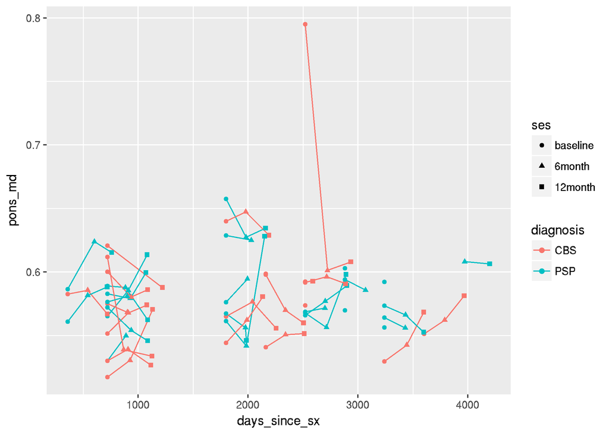

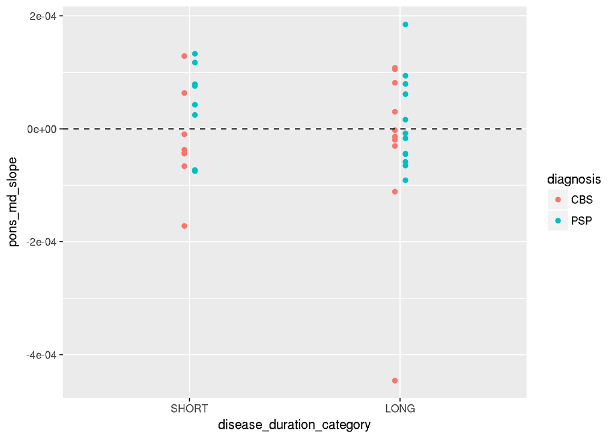

t.test for SHORT vs LONG group diff in slope among CBS:

```r
t.test(pons_md_slope~disease_duration_category, data=mydata_long,subset= diagnosis=="CBS")$p.value
```

```
## [1] 0.904779
```

t.test for SHORT vs LONG group diff in slope among PSP:

```r
t.test(pons_md_slope~disease_duration_category, data=mydata_long,subset= diagnosis=="PSP")$p.value
```

```
## [1] 0.4011142
```

# Occipital FA

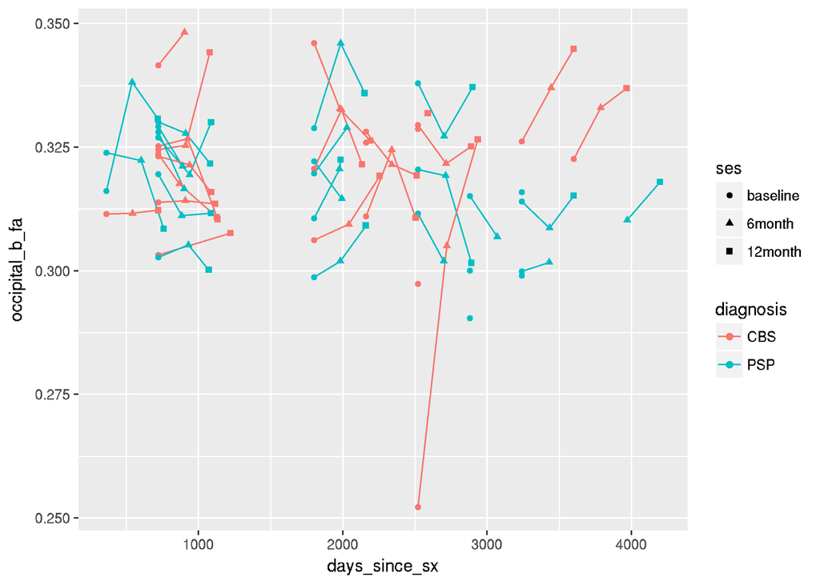

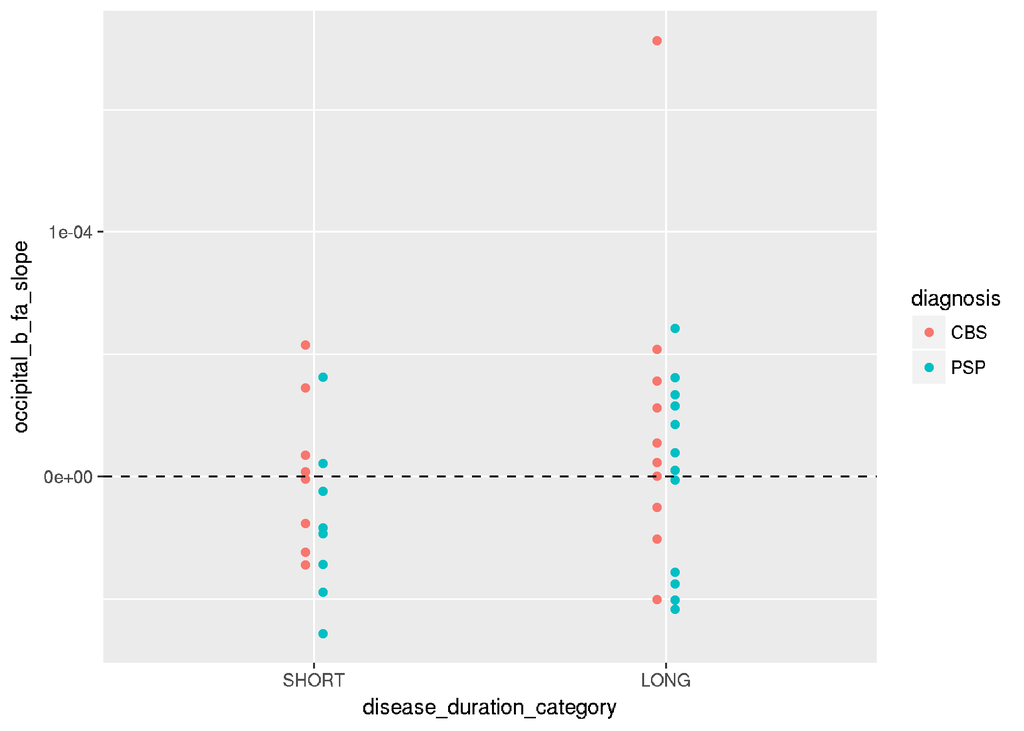

t.test for SHORT vs LONG group diff in slope among CBS:

```r
t.test(occipital_b_fa_slope~disease_duration_category, data=mydata_long,subset= diagnosis=="CBS")$p.value
```

```
## [1] 0.3663093
```

t.test for SHORT vs LONG group diff in slope among PSP:

```r
t.test(occipital_b_fa_slope~disease_duration_category, data=mydata_long,subset= diagnosis=="PSP")$p.value
```

```
## [1] 0.2411092
```

# ======== Anatomical Measures =========

# Superior Cerebellar Peduncle Volume

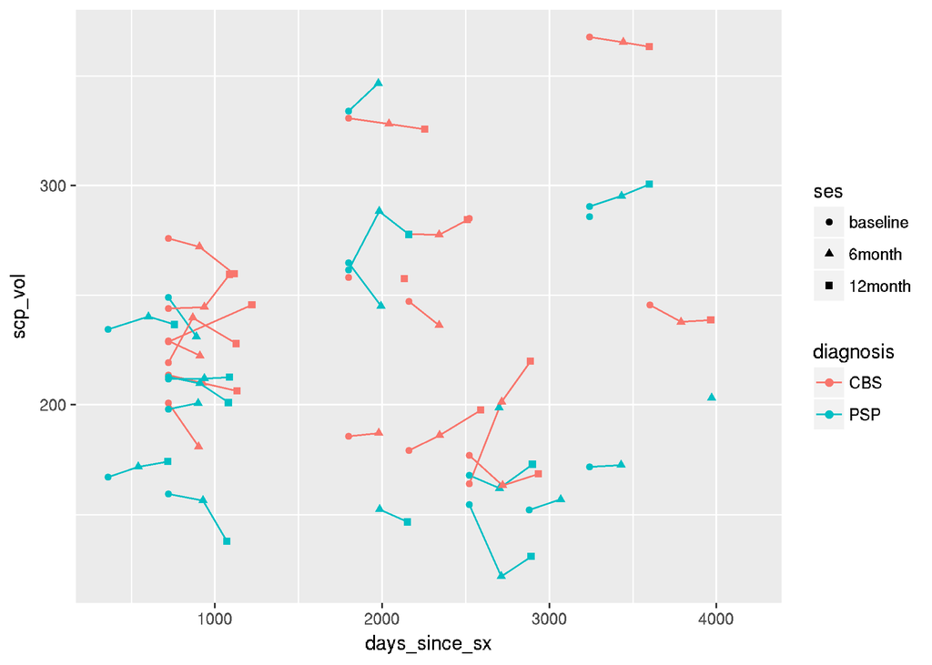

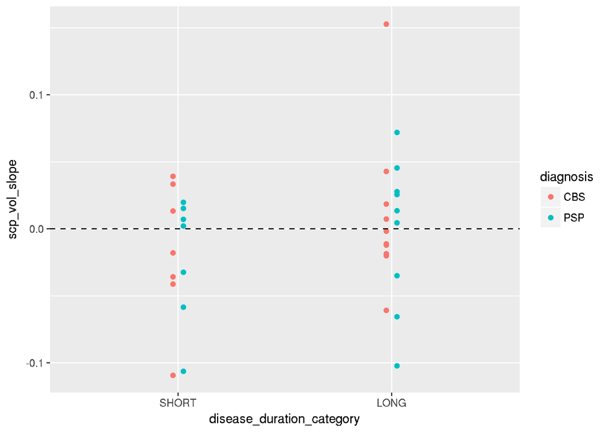

t.test for SHORT vs LONG group diff in slope among CBS:

```r
t.test(scp_vol_slope~disease_duration_category, data=mydata_long,subset= diagnosis=="CBS")$p.value
```

```
## [1] 0.3357956
```

t.test for SHORT vs LONG group diff in slope among PSP:

```r
t.test(scp_vol_slope~disease_duration_category, data=mydata_long,subset= diagnosis=="PSP")$p.value
```

```
## [1] 0.4400818
```

# Corpus Callosum Volume

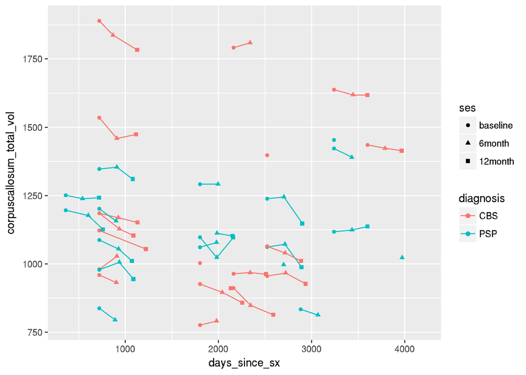

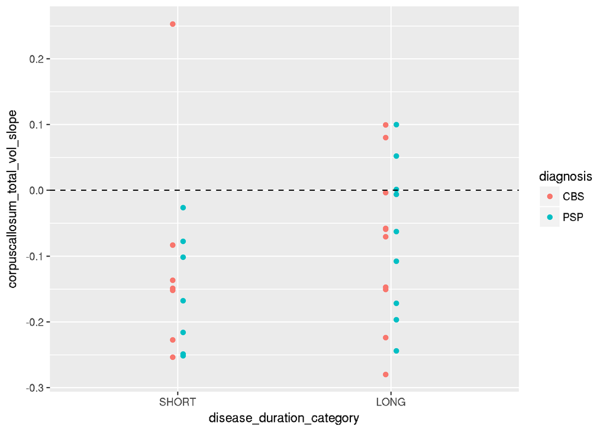

t.test for SHORT vs LONG group diff in slope among CBS:

```r
t.test(corpuscallosum_total_vol_slope~disease_duration_category, data=mydata_long,subset= diagnosis=="CBS")$p.value
```

```
## [1] 0.7370064
```

t.test for SHORT vs LONG group diff in slope among PSP:

```r
t.test(corpuscallosum_total_vol_slope~disease_duration_category, data=mydata_long,subset= diagnosis=="PSP")$p.value
```

```
## [1] 0.122007
```

# Caudate Volume

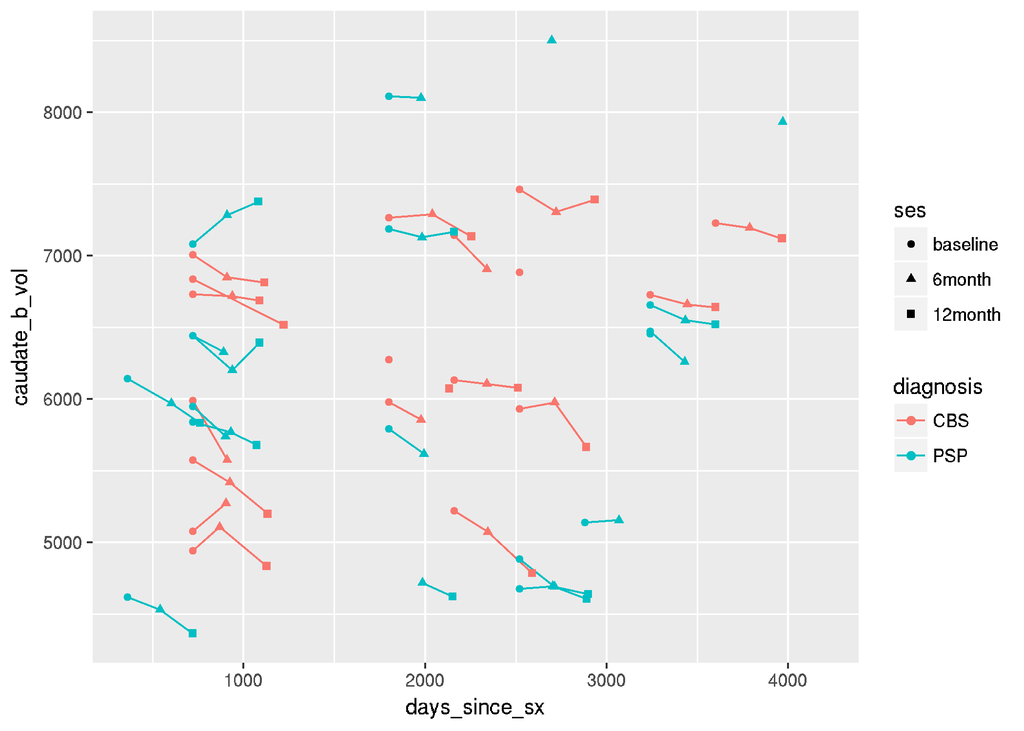

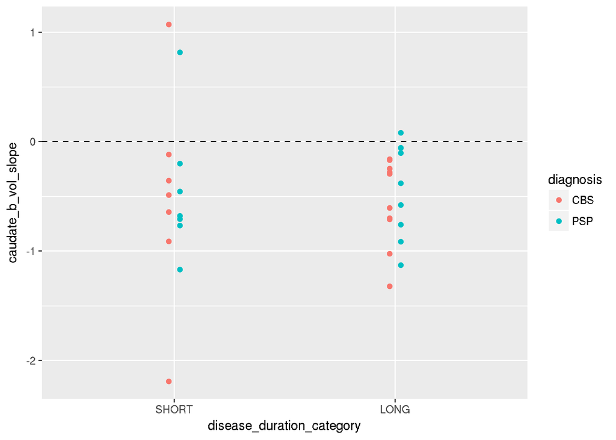

t.test for SHORT vs LONG group diff in slope among CBS:

```r
t.test(caudate_b_vol_slope~disease_duration_category, data=mydata_long,subset= diagnosis=="CBS")$p.value
```

```
## [1] 0.9364953
```

t.test for SHORT vs LONG group diff in slope among PSP:

```r
t.test(caudate_b_vol_slope~disease_duration_category, data=mydata_long,subset= diagnosis=="PSP")$p.value
```

```
## [1] 0.9497582
```

# Thalamus Volume

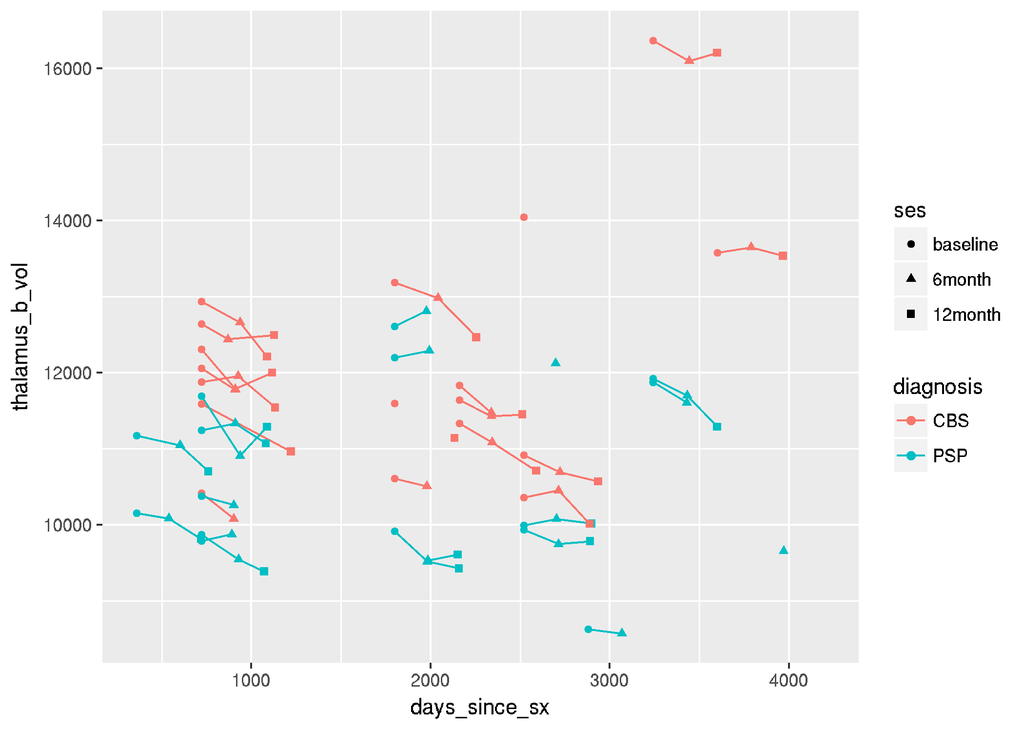

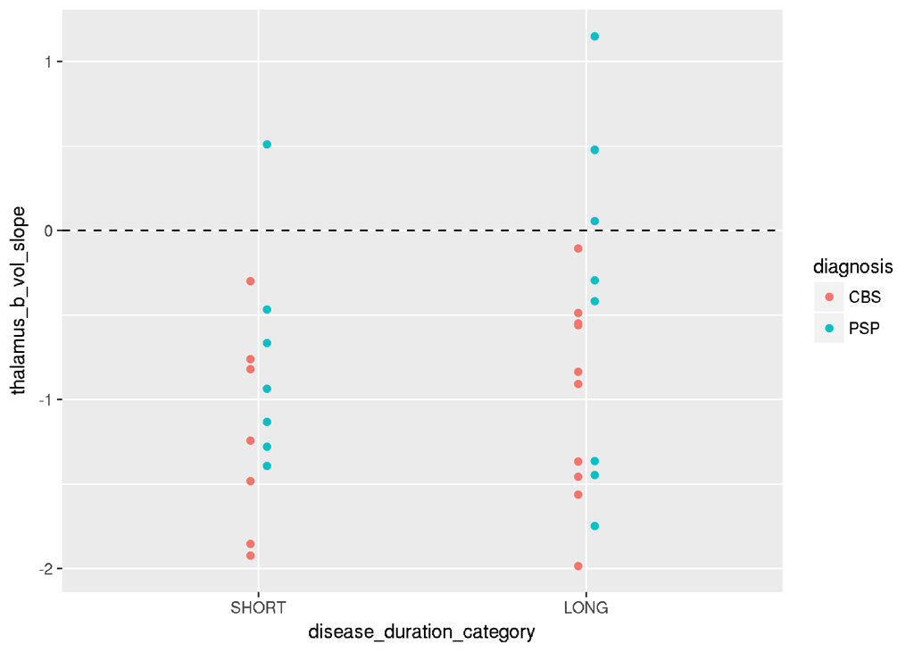

t.test for SHORT vs LONG group diff in slope among CBS:

```r
t.test(thalamus_b_vol_slope~disease_duration_category, data=mydata_long,subset= diagnosis=="CBS")$p.value
```

```
## [1] 0.4767954
```

t.test for SHORT vs LONG group diff in slope among PSP:

```r
t.test(thalamus_b_vol_slope~disease_duration_category, data=mydata_long,subset= diagnosis=="PSP")$p.value
```

```
## [1] 0.3272338
```

# Midbrain Volume

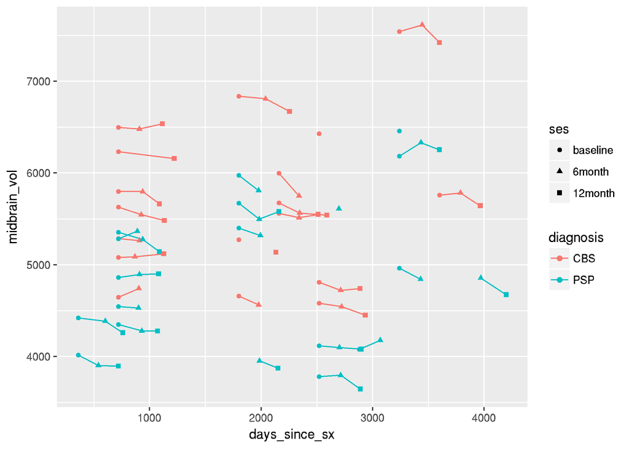

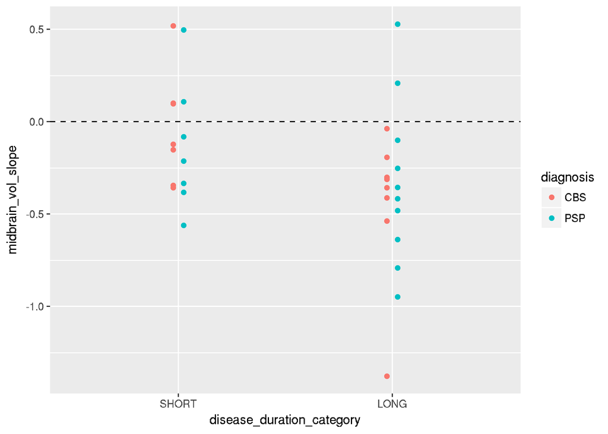

t.test for SHORT vs LONG group diff in slope among CBS:

```r
t.test(midbrain_vol_slope~disease_duration_category, data=mydata_long,subset= diagnosis=="CBS")$p.value
```

```
## [1] 0.03605806
```

t.test for SHORT vs LONG group diff in slope among PSP:

```r
t.test(midbrain_vol_slope~disease_duration_category, data=mydata_long,subset= diagnosis=="PSP")$p.value
```

```
## [1] 0.353079
```